# Piloting the prior knowledge assessment

Stefanie Meliss

2024-05-03

### Description of the pilot study

The purpose of this pilot study was to administer the prior knowledge assessment to teachers to determine whether the items possess the right level of difficulty. The prior knowledge assessment was designed for the use in this project (by CS & SA). In addition to an empirical variance measure for each of the ten prior knowledge questions, we also collected feedback on the assessment.

##### Participants

Participants were recruited using Twitter. The pilot study was set up in Qualtrics and a distribution link was shared (by SS). In total, the survey was started by 194 participants and completed by **111** participants. The project protocol was approved by University College London’s ethics committee. Participants were informed about the purpose and provided informed consent to participate in the pilot study.

##### Materials and measurements

The prior knowledge assessment consisted of ten four-alternative forced choice questions/statements. For each presented item (e.g., “A grapheme is an individual letter or a group of letters that represents…” ), participants were instructed to select the answer out of four alternatives they thought as correct (e.g., “A syllable.”, “A phoneme.”, “A word.”, “A morpheme.”). Participants were encouraged to guess but specifically asked to not look up any correct answers. The items and corresponding options were presented in randomised, but constant order, i.e., a custom-made R script was used to randomise the presentation order and the same order was used across all participants.  
The feedback survey consisted of in total six items. We asked participants to rate the amount and difficulty of questions (bipolar 5-point Likert scale from -2 = “too few”/“too easy” to +2 = “too many”/“too difficult”). Participants were additionally instructed to choose the midpoint to indicate that the questions were neither too few/too easy nor too many/too difficult. Lastly, a 5-point Likert scale (1 = “strongly disagree”, 5 = “strongly agree”) was presented to participants to obtain ratings regarding the wording of the questions (e.g., “The questions in the multiple choice test are worded in a way that is concise.”) For each ratings, an optional free-text input text box was added, offering participants to opportunity to expand on their rating.

##### Procedure

Upon following the Qualtrics survey distribution link, participants were informed about the purpose of the study and asked to provide consent. No identifiable information was recorded but participants were asked to create a study pseudonym should they wish to withdraw their consent. Participants then completed the prior knowledge assessment (presented on a single page) followed by the feedback survey (presented on one page). Participants took on average **5.81min** to complete the pilot study.

### Performance in the prior knowledge assessment

To determine how participants performed in the prior knowledge assessment, the selected response was compared to the correct response using custom-made R scripts and points were awarded if the correct response was selected. The total score was calculated as the sum of points obtained in all 10 items.

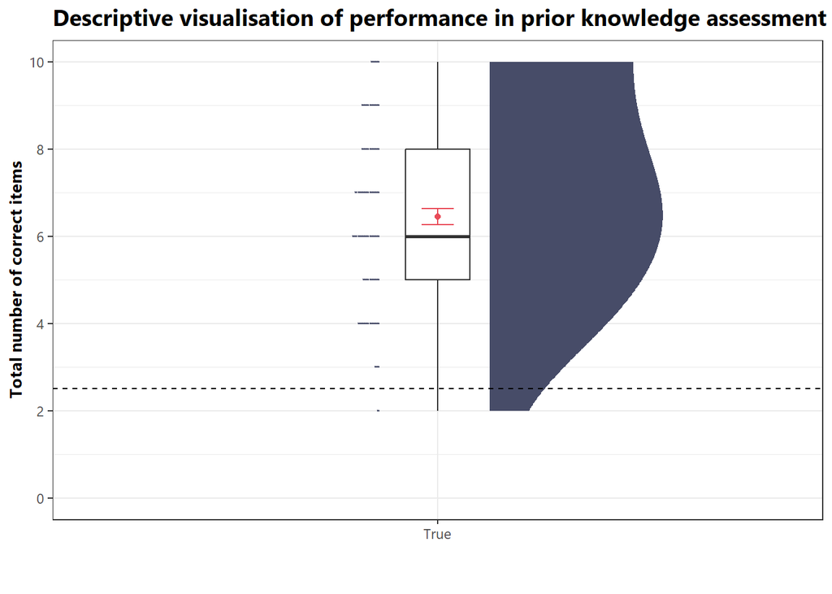

Above, a “raincloud” plot was used to visualise the data. A raincloud plot used here combines a half violin plot (illustrating the distribution of the data, i.e., the navy-coloured cloud) with a boxplot (showing summary statistics, i.e., rectangle with whiskers) and a dot plot (capturing the raw data, i.e., the navy-coloured rain). Additionally, the mean (+/- standard error) were added in coral together with a horizontal line marking chance level performance.

Descriptive statistics can further be found in the table below.

| n | mean | sd | median | trimmed | mad | min | max | range | skew | kurtosis | se |
| --- | --- | --- | --- | --- | --- | --- | --- | --- | --- | --- | --- |
| 111 | 6.45045 | 1.998812 | 6 | 6.449438 | 2.9652 | 2 | 10 | 8 | -0.0361384 | -0.8506899 | 0.1897188 |

After determining whether the total score was normally distributed, the appropriate statistical test (i.e., one-Sample t-test or the non-parametric Wilcoxon signed rank test) was used to determine whether the performance was significantly better than chance (i.e., randomly picking the correct out of 4 alternatives, 1/4 = 25%).

```
##
##  Wilcoxon signed rank test with continuity correction
##
## data:  df$q_total
## V = 6209, p-value < 0.00000000000000022
## alternative hypothesis: true location is greater than 2.5
```

In addition to the total test score, each item was examined separately. For this, the proportion of correct responses was plotted for each item below. The dotted horizontal line represents chance-level performance. The error bars represent the 95% confidence intervals estimated based upon binomial tests, testing the null hypothesis that the number of correct responses is greater than chance level.

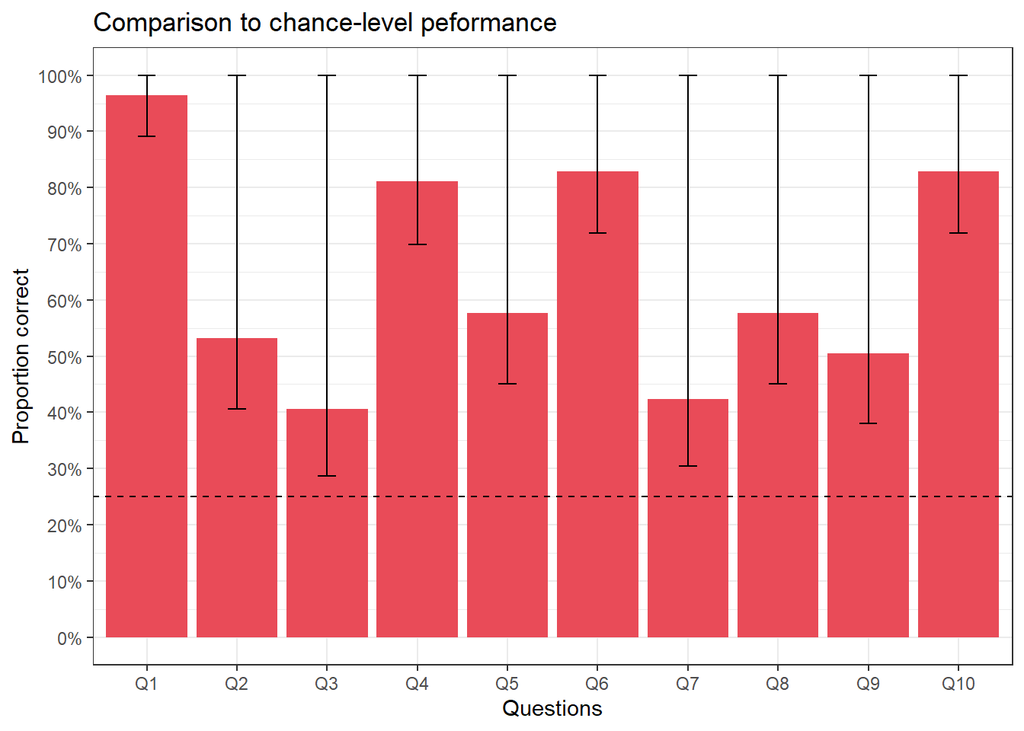

Further, answer patterns in each question were investigated by plotting the proportion each response option was selected with. The corresponding item text and answer options were also included. The correct answer was highlighted in coral.

##### Q1

**Question: Pupils make inferences when they read…** *[ correct: All types of text. ]*

Option 1: All types of text.  
Option 2: Fiction texts only.  
Option 3: Non-fiction texts only.  
Option 4: But not when they read independently.

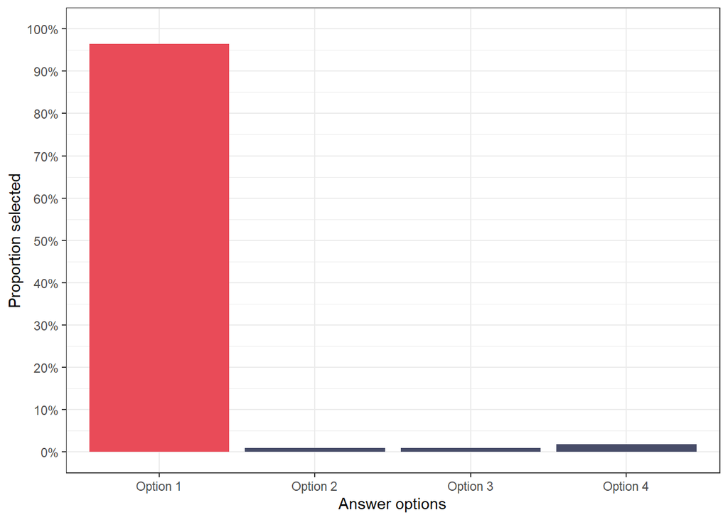

##### Q2

**Question: Which of these comprehension strategies does not have a sound basis in evidence?** *[ correct: Extrapolating. ]*

Option 1: Summarising.  
Option 2: Clarifying.  
Option 3: Self-questioning.  
Option 4: Extrapolating.

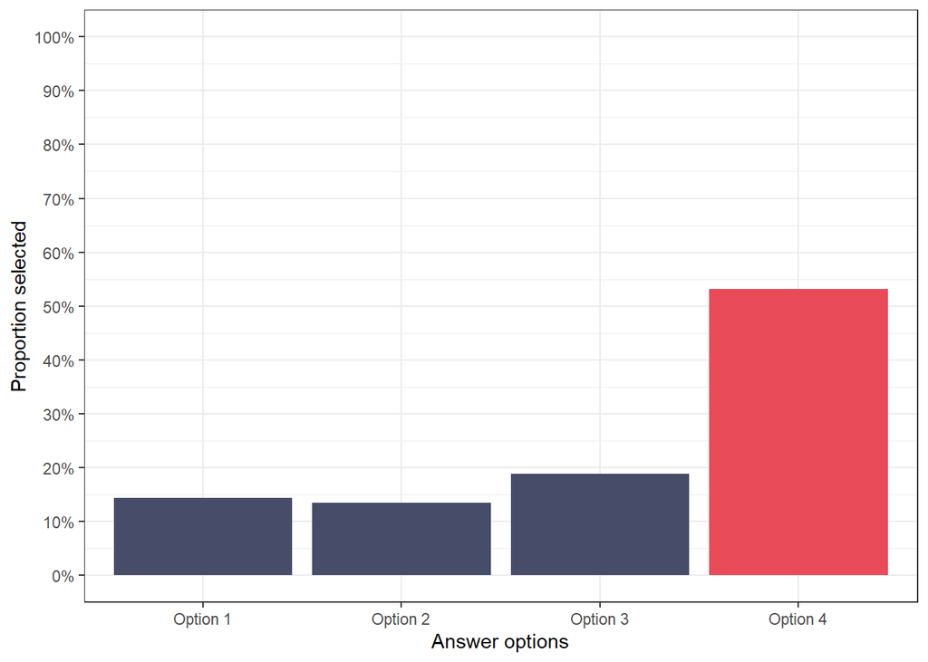

##### Q3

**Question: Alongside chunks of spoken sound, the English writing system represents the smallest chunks within words that are associated with meaning called…** *[ correct: Morphemes. ]*

Option 1: Morphemes.  
Option 2: Lexemes.  
Option 3: Syntactic identifiers.  
Option 4: Graphemes.

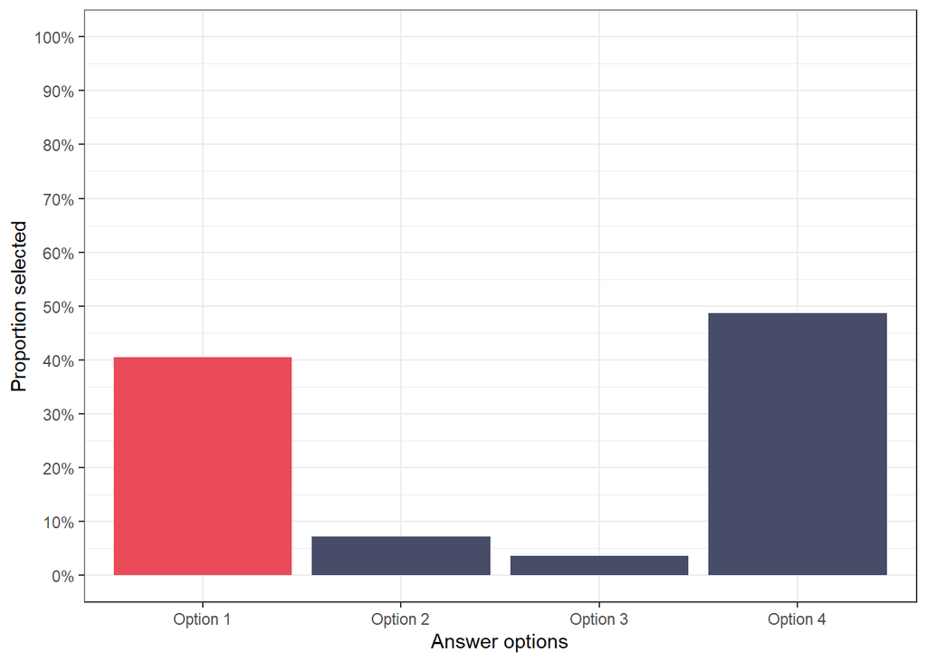

##### Q4

**Question: A grapheme is an individual letter or a group of letters that represents…** *[ correct: A phoneme. ]*

Option 1: A syllable.  
Option 2: A phoneme.  
Option 3: A word.  
Option 4: A morpheme.

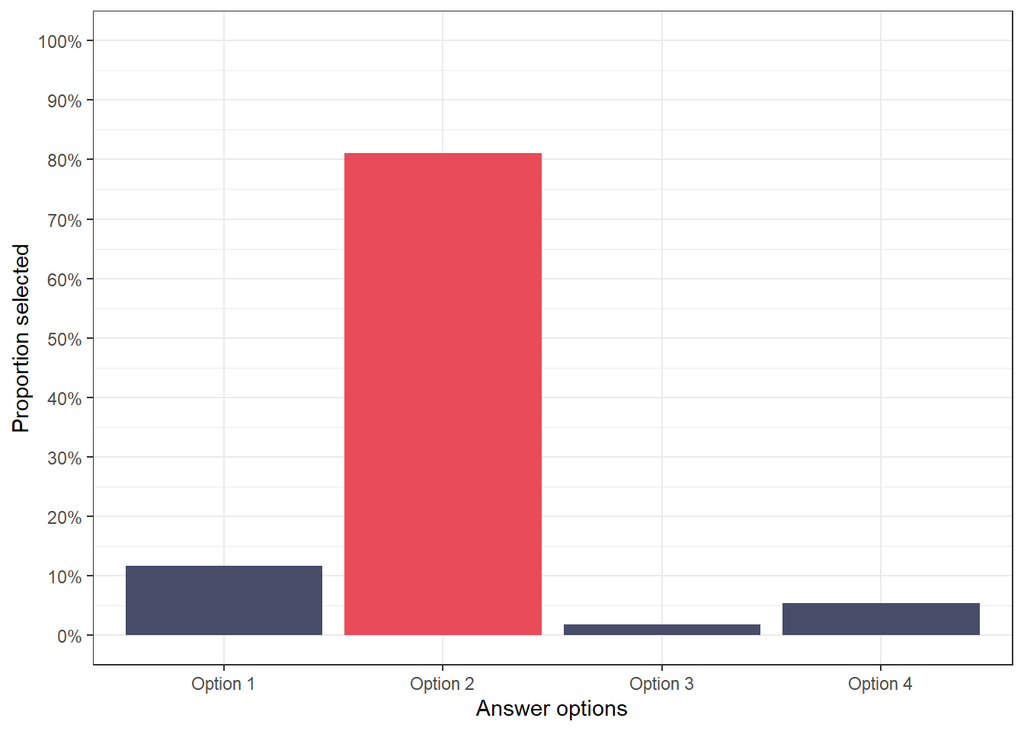

##### Q5

**Question: Reading fluency is commonly identified through three properties of oral reading called…** *[ correct: Accuracy, automaticity and prosody. ]*

Option 1: Accuracy, automaticity and semantics.  
Option 2: Accuracy, automaticity and prosody.  
Option 3: Accuracy, automaticity and syntax.  
Option 4: Accuracy, automaticity and flow.

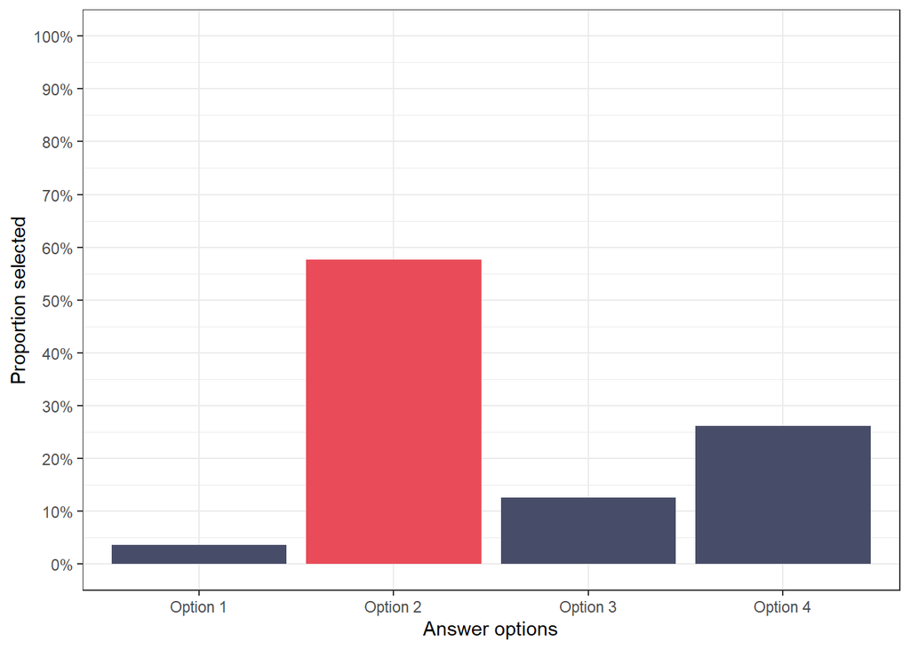

##### Q6

**Question: Reading fluency contributes to reading comprehension by…** *[ correct: Freeing up the cognitive resources that can be devoted to building meaning from words. ]*

Option 1: Allowing readers to flow through text without identifying all of the words on a page.  
Option 2: Significantly reducing the pupil’s reliance on background knowledge.  
Option 3: Increasing pupils’ working memory capacity.  
Option 4: Freeing up the cognitive resources that can be devoted to building meaning from words.

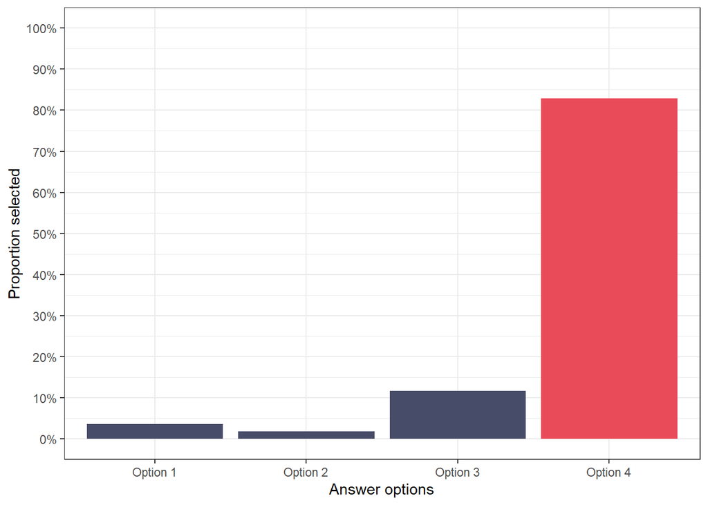

##### Q7

**Question: A phoneme can be thought of as…** *[ correct: The smallest chunk of spoken sound that can distinguish one word from another. ]*

Option 1: The chunk of sound associated with a morpheme.  
Option 2: The chunk of sound associated with a syllable.  
Option 3: The smallest chunk of spoken sound that can distinguish one word from another.  
Option 4: Any chunk of sound that is smaller than a whole word.

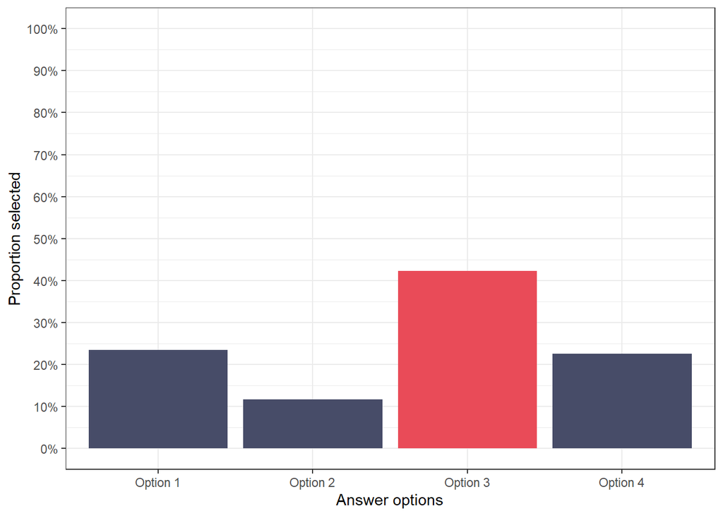

##### Q8

**Question: An orthography is…** *[ correct: The set of conventions associated with a written language. ]*

Option 1: The set of conventions associated with a phonics programme.  
Option 2: The set of conventions associated with a written language.  
Option 3: The set of conventions associated with a handwriting system.  
Option 4: The set of conventions associated with a spoken language.

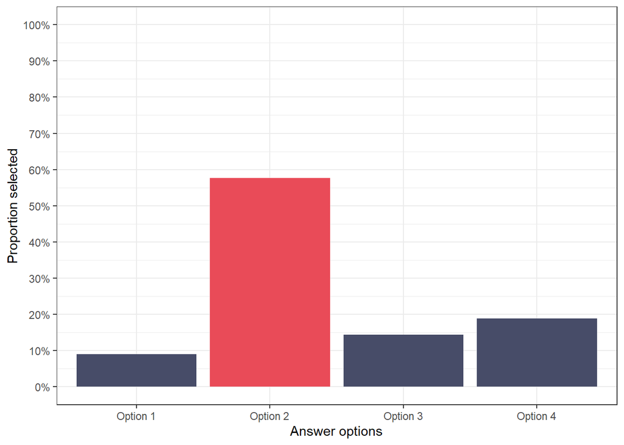

##### Q9

**Question: Reading comprehension can be described as relying on two capacities: the ability to recognise words and build meaning from words. These are generally described as…** *[ correct: Word recognition and language comprehension. ]*

Option 1: Word recognition and background knowledge.  
Option 2: Word recognition and language comprehension.  
Option 3: Word recognition and reading comprehension.  
Option 4: Word recognition and fluency.

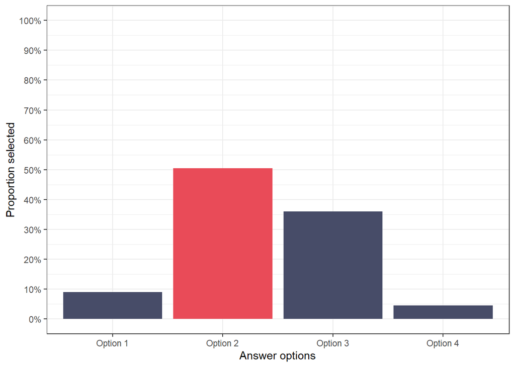

##### Q10

**Question: Tier 3 vocabulary can be thought of as words that…** *[ correct: Are more likely to be found in an academic context and are associated with a particular academic subject or subjects. ]*

Option 1: Pupils are likely to learn through their everyday interactions.  
Option 2: Are more likely to be found in an academic context and are not associated with a given academic subject.  
Option 3: Are found primarily in narrative texts.  
Option 4: Are more likely to be found in an academic context and are associated with a particular academic subject or subjects.

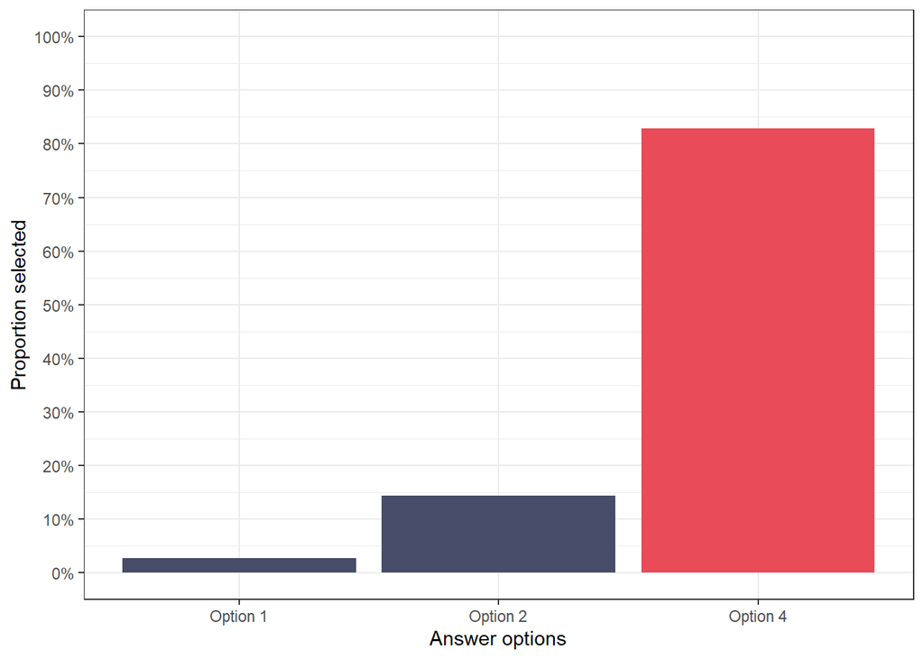

### Feedback survey

Feedback regarding the prior knowledge test was evaluated.

##### Amount of questions

The raincloud plot below illustrate how participants have rated the item.

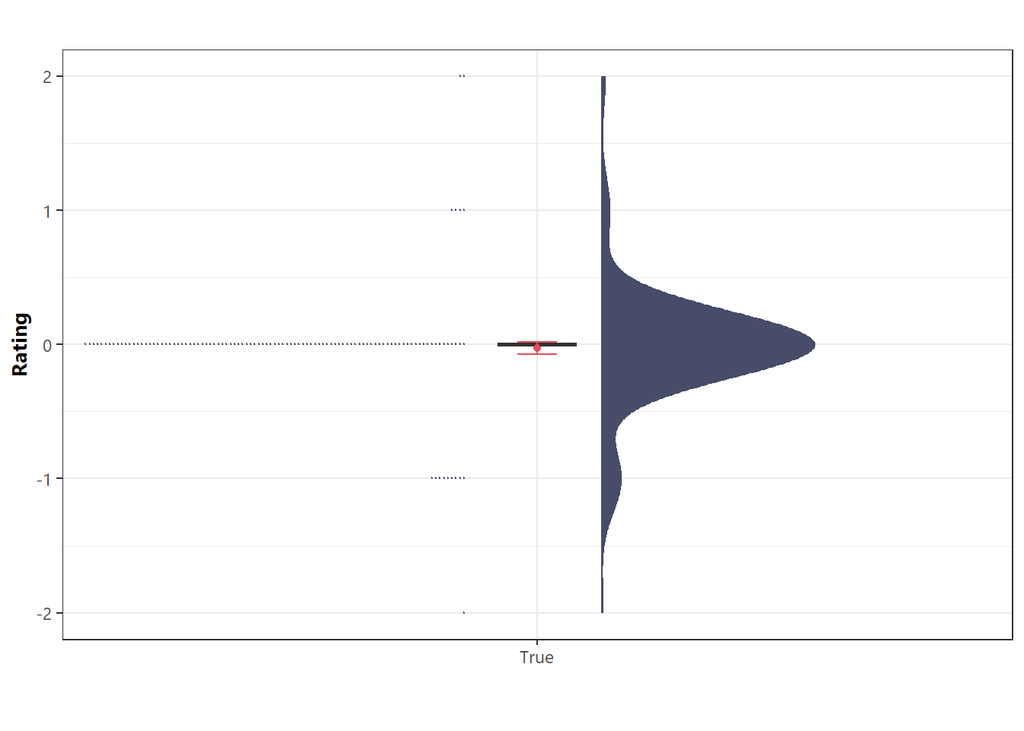

Descriptive statistics associated with the ratings are shown below. Please note that “too few” was coded as -2 whereas “too many” was coded as +2. An average rating of/close to zero would represent that the amount of question was neither too few nor too many.

| n | mean | sd | median | trimmed | mad | min | max | range | skew | kurtosis | se |
| --- | --- | --- | --- | --- | --- | --- | --- | --- | --- | --- | --- |
| 111 | -0.027027 | 0.4759576 | 0 | 0 | 0 | -2 | 2 | 4 | 0.4196669 | 7.784767 | 0.0451759 |

Whether the observed rating was significantly different from zero was determined using (non-)parametric tests.

```
##
##  Wilcoxon signed rank test with continuity correction
##
## data:  df$quest_amount_score
## V = 58, p-value = 0.5999
## alternative hypothesis: true location is not equal to 0
```

Participants were also provided with the option to expand on the rating using comments.

```
##
##
## Didn't feel long
##
## Perfect amount for busy teachers
```

##### Difficulty of questions

Similar to the amount of questions, the difficulty of questions was rated using a bipolar Likert scale (-2 = “too easy”, +2 = “too difficult”). The ratings provided by participants are plotted below.

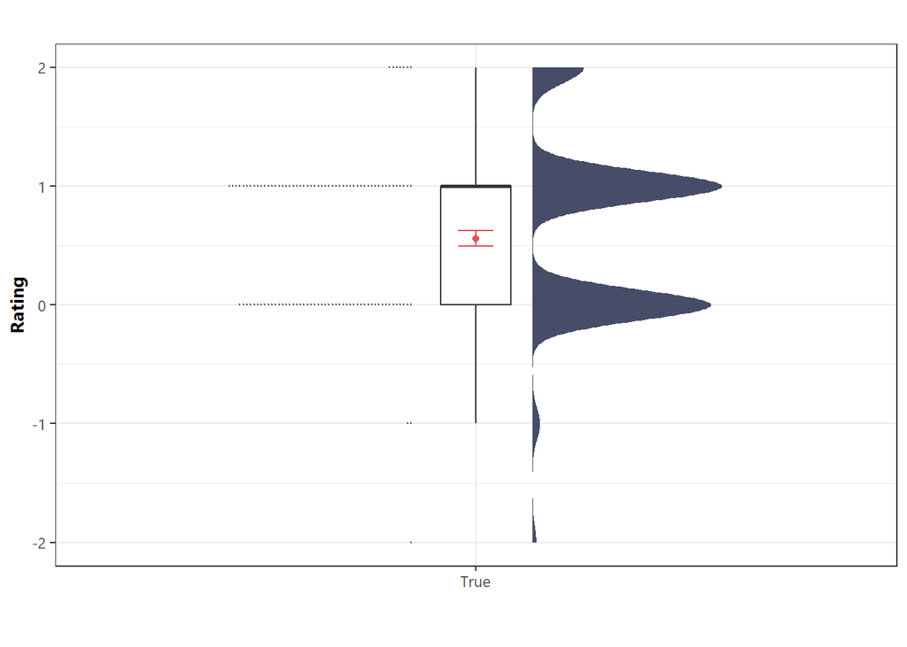

Descriptive summary statistics of the difficulty rating were computed and statistically compared against zero.

| n | mean | sd | median | trimmed | mad | min | max | range | skew | kurtosis | se |
| --- | --- | --- | --- | --- | --- | --- | --- | --- | --- | --- | --- |
| 111 | 0.5585586 | 0.6833698 | 1 | 0.5393258 | 1.4826 | -2 | 2 | 4 | -0.2095123 | 0.7847157 | 0.0648626 |

```
##
##  Wilcoxon signed rank test with continuity correction
##
## data:  df$quest_difficulty_score
## V = 1839.5, p-value = 0.00000000003985
## alternative hypothesis: true location is not equal to 0
```

Participants were also provided with the option to expand on the rating using comments.

```
##
##
## Moderately challenging- I question the reason behind so many definition questions unless it is specifically about establishing a shared language rather than understanding concepts and learning in practice.
##
## Too many questions about the terms for things rather than actual understanding. Which is ironic.
##
## I realized as a high school teacher that I don’t know as much as I’d like about how students learn to read.
##
## The difficulty level is personal to the person answering and their subject knowledge. I am a maths specialist, so I would find maths questions easier. I found these tricky, as I haven’t got a sound knowledge of the complexity of terminology of the subject.
##
## Seems to be geared towards primary rather than secondary.
##
## I don’t think most teachers could answer these.
##
## I was certain about some answers, some I was not certain of, and I think there was one I guessed
##
## Secondary teacher- only know what I have picked up. Never been trained in this stuff.
##
## Hard to judge because I'm not sure about some answers
##
## The language was technical and the majority of people would not know those specific words. I am a phonics leader and needed to think carefully about them!
##
## I don't have a lot of knowledge on this area so it may be that others would find it less difficult.
##
## I found some tricky but they were things I should know so I can't say they in themselves were too difficult!
##
## The questions are very precise and granular. They are so granular as to potentially promote a focus on definitions over understanding. No questions imply any understanding of applied knowledge, so I’m not sure how valid the MCQs prove?
##
## I associate orthography with spelling so I was having a hard time choosing between the phonics and written language choices.
##
## I teach science and didn't recognise many technical terms apart from tiers of language
##
## I have realised how little I know about this
##
## Quite difficult as English is not my first subject and the questions were cognitively demanding. I had to re-read several times to understand them and their relationship to the answers
##
## There is a lot of reliance on vicabulary knowledge of the reading system. Sometimes teachers understand conceptually but may not have the specific vocab term - could some specific examples help expand insight into their understanding that isn’t solely depended on knowledge of graphemes, phonemes …
##
## Difficult for me as my background knowledge of science of reading is quite low!
```

#### Other ratings

Lastly, a 5-point Likert scale rating matrix was presented to participants to obtain further ratings on the questions. Each item was rated on a scale from -2 (“strongly disagree”) to 2 (“strongly agree”). Raincloud plots were used to visualise distribution and summary statistics for each rating.

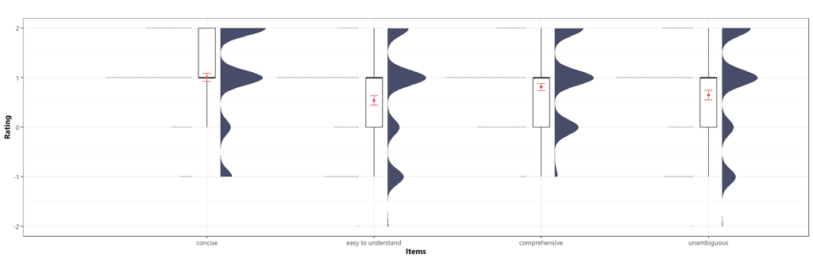

Additional descriptive statistics were computed and included below.

| vars | n | mean | sd | median | trimmed | mad | min | max | range | skew | kurtosis | se |
| --- | --- | --- | --- | --- | --- | --- | --- | --- | --- | --- | --- | --- |
| concise | 111 | 1.0090090 | 0.8366111 | 1 | 1.1011236 | 0.0000 | -1 | 2 | 3 | -0.7551250 | 0.2133128 | 0.0794076 |
| easy to understand | 111 | 0.5405405 | 0.9980325 | 1 | 0.5617978 | 1.4826 | -2 | 2 | 4 | -0.4640688 | -0.7920367 | 0.0947290 |
| comprehensive | 111 | 0.8108108 | 0.7688659 | 1 | 0.8089888 | 1.4826 | -1 | 2 | 3 | -0.1455083 | -0.4906885 | 0.0729775 |
| unambiguous | 111 | 0.6486486 | 1.0148771 | 1 | 0.6966292 | 1.4826 | -2 | 2 | 4 | -0.5064639 | -0.7002678 | 0.0963279 |

Participants were also provided with the option to expand on the rating using comments.

```
##
##
## 'Generally understood as' is problematic- are you asking what the teacher thinks it is or what their colleagues/wider profession thinks it is?
##
## Knowing the terms some people use to describe things is not the same as understanding reading.
##
## I think some of the granular definitions are ambiguous in the research literature, but very precise in the MCQs. This may create an illusion of understanding or misunderstanding.
##
## Really enjoyed this! Thanks!
##
## I don't know what is meant by "self-questioning" in one of the multiple choice options.
##
## (I think) there's decent evidence for summarising, if summarising is taught and practised.
##
## It could be argued the responders context could alter the way the questions were interpreted. I had engineering students in my head as I was answering one question
```

##### Intercorrelation matrix of all ratings

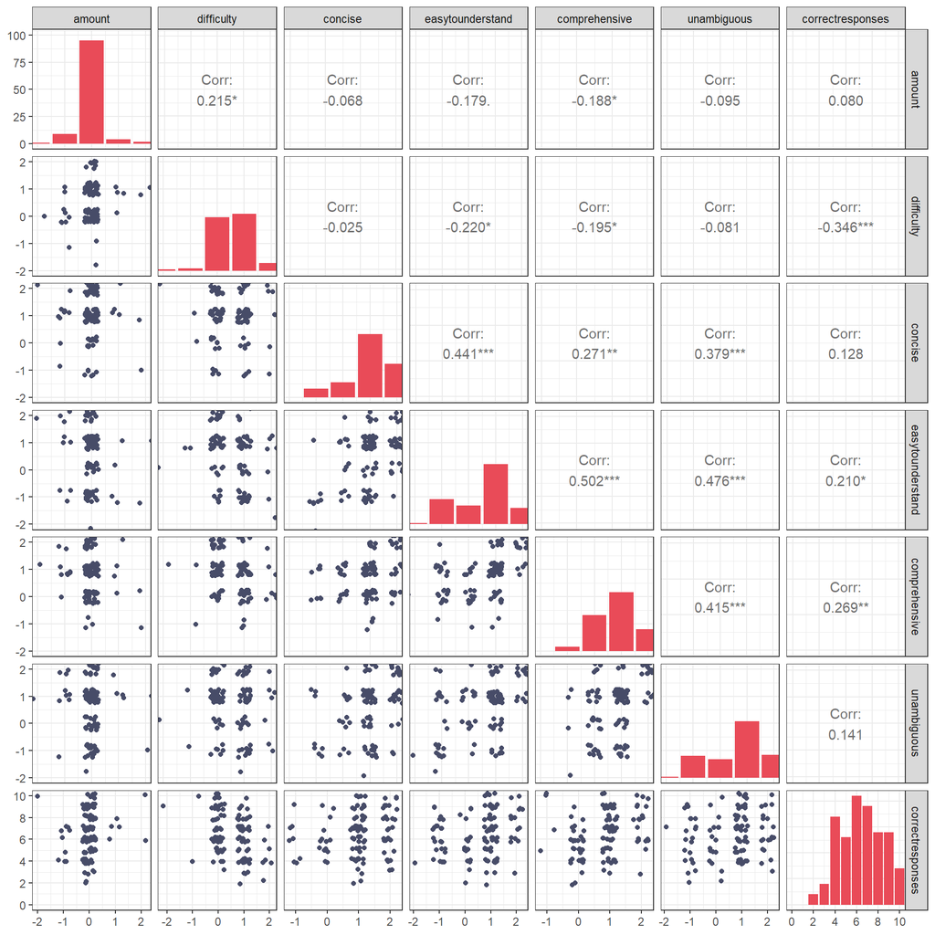

##### Item Response Theory (IRT)

To create an index of prior knowledge, it is possible to simply add up items to a sum score as done above. However, measurement theories and more specifically item response theory (IRT) can be applied to measure the latent knowledge score. IRT models have three parameters:

- *discrimination* (i.e., ability of an item to differentiate between respondents with different levels of proficiency)
- *difficulty* (i.e., likelihood of a correct response, expressed as the proficiency level at which 50% of the participant sample is estimated to answer an item correctly)
- *guessing probability*

As a first step, a uni-dimensional model is specified and the data for each item is supplied to the model before fitting the model using the *‘mirt package’* (Chalmers, 2012). A 2PL and a 3PL model were fitted, however, as shown below, the 3PL model did not fit the data and hence, the simpler 2PL model was preferred.

```
##
## Call:
## mirt(data = df[, paste0("Q", c(1:10), "_score")], model = unimodel,
##     itemtype = "2PL", verbose = FALSE)
##
## Full-information item factor analysis with 1 factor(s).
## Converged within 0.0001 tolerance after 28 EM iterations.
## mirt version: 1.41
## M-step optimizer: BFGS
## EM acceleration: Ramsay
## Number of rectangular quadrature: 61
## Latent density type: Gaussian
##
## Log-likelihood = -602.7792
## Estimated parameters: 20
## AIC = 1245.558
## BIC = 1299.749; SABIC = 1236.545
## G2 (1003) = 270.43, p = 1
## RMSEA = 0, CFI = NaN, TLI = NaN
```

```
##
## Call:
## mirt(data = df[, paste0("Q", c(1:10), "_score")], model = unimodel,
##     itemtype = "3PL", verbose = FALSE)
##
## Full-information item factor analysis with 1 factor(s).
## Converged within 0.0001 tolerance after 445 EM iterations.
## mirt version: 1.41
## M-step optimizer: BFGS
## EM acceleration: Ramsay
## Number of rectangular quadrature: 61
## Latent density type: Gaussian
##
## Log-likelihood = -595.504
## Estimated parameters: 30
## AIC = 1251.008
## BIC = 1332.294; SABIC = 1237.488
## G2 (993) = 255.88, p = 1
## RMSEA = 0, CFI = NaN, TLI = NaN
```

```
##             AIC    SABIC       HQ      BIC   logLik    X2 df     p
## fit2PL 1245.558 1236.545 1267.542 1299.749 -602.779
## fit3PL 1251.008 1237.488 1283.983 1332.294 -595.504 14.55 10 0.149
```

To understand the IRT parameters, the so-called factor solution including factor loadings (F1) and the communalities (h2), which are squared factor loadings and are interpreted as the variance accounted for in an item by the latent trait. Substantive relationship with the latent trait are defined as loadings > .50.

```
##              F1     h2
## Q1_score  0.569 0.3243
## Q2_score  0.528 0.2788
## Q3_score  0.539 0.2902
## Q4_score  0.160 0.0256
## Q5_score  0.663 0.4390
## Q6_score  0.347 0.1204
## Q7_score  0.384 0.1471
## Q8_score  0.523 0.2731
## Q9_score  0.346 0.1198
## Q10_score 0.579 0.3347
##
## SS loadings:  2.353
## Proportion Var:  0.235
##
## Factor correlations:
##
##    F1
## F1  1
```

The 2PL model takes item discrimination (first parameter: a) and item difficulty (second parameter: b) into account while guessing probability (third parameter: c or g) is held constant.

Parameter a represents the values of the slope and the values fairly evenly distributed in the 2PL model, yet larger values, i.e., steeper slopes are better at differentiating people as higher slope value indicate stronger relationships between item and latent trait.

The location or difficulty parameters (parameter b) is also listed for each item. Location parameters are interpreted as the value of theta that corresponds to a .50 probability of responding correctly at or above that location on an item. The location parameters show that the items cover a wide range of the latent trait in the negative, but not the positive direction.

```
##              a     b g u
## Q1_score  1.18 -3.29 0 1
## Q2_score  1.06 -0.15 0 1
## Q3_score  1.09  0.43 0 1
## Q4_score  0.28 -5.36 0 1
## Q5_score  1.51 -0.30 0 1
## Q6_score  0.63 -2.70 0 1
## Q7_score  0.71  0.48 0 1
## Q8_score  1.04 -0.37 0 1
## Q9_score  0.63 -0.03 0 1
## Q10_score 1.21 -1.65 0 1
```

Below, the model fit is quantified using *M2*, a statistic designed to assess the fit of IRT models. The IRT model results in a non-significant M2 statistic, indicating that there is no significant difference between the model and the data.

```
##             M2 df         p RMSEA RMSEA_5   RMSEA_95      SRMSR      TLI CFI
## stats 32.75312 35 0.5770317     0       0 0.06215182 0.07365723 1.048625   1
```

Item characteristic curves visualise the IRT parameters for each item to help understand the properties of each item. As illustrated below and in alignment with what has been said above, the items predominantly differentiate among the negative values of theta and particularly close to zero.

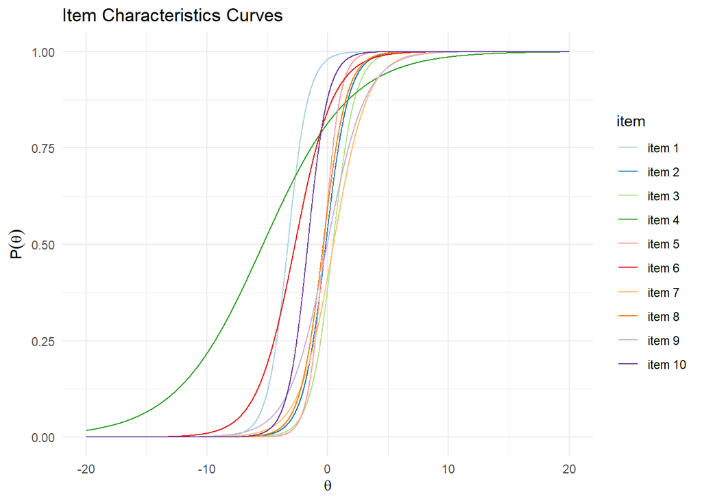

Information curves (plotted below) refer to the ability of an item to estimate theta scores.

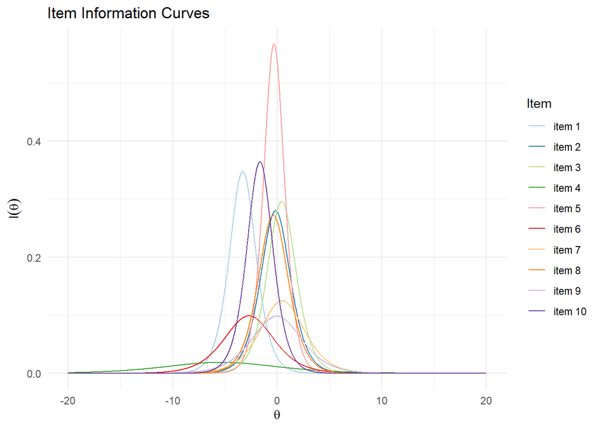

```r
ggmirt::itemInfoPlot(fit2PL, theta_range = c(-20, 20), legend = T) + scale_color_brewer(palette = "Paired")
```

IRT can also be used to estimate the latent score of each subject. The descriptives are included and plotted below.

|  | vars | n | mean | sd | median | trimmed | mad | min | max | range | skew | kurtosis | se |
| --- | --- | --- | --- | --- | --- | --- | --- | --- | --- | --- | --- | --- | --- |
| X1 | 1 | 111 | -0.0000276 | 0.7786938 | -0.012488 | -0.0039667 | 0.8967154 | -1.589266 | 1.397598 | 2.986864 | 0.0035763 | -0.9224291 | 0.0739103 |

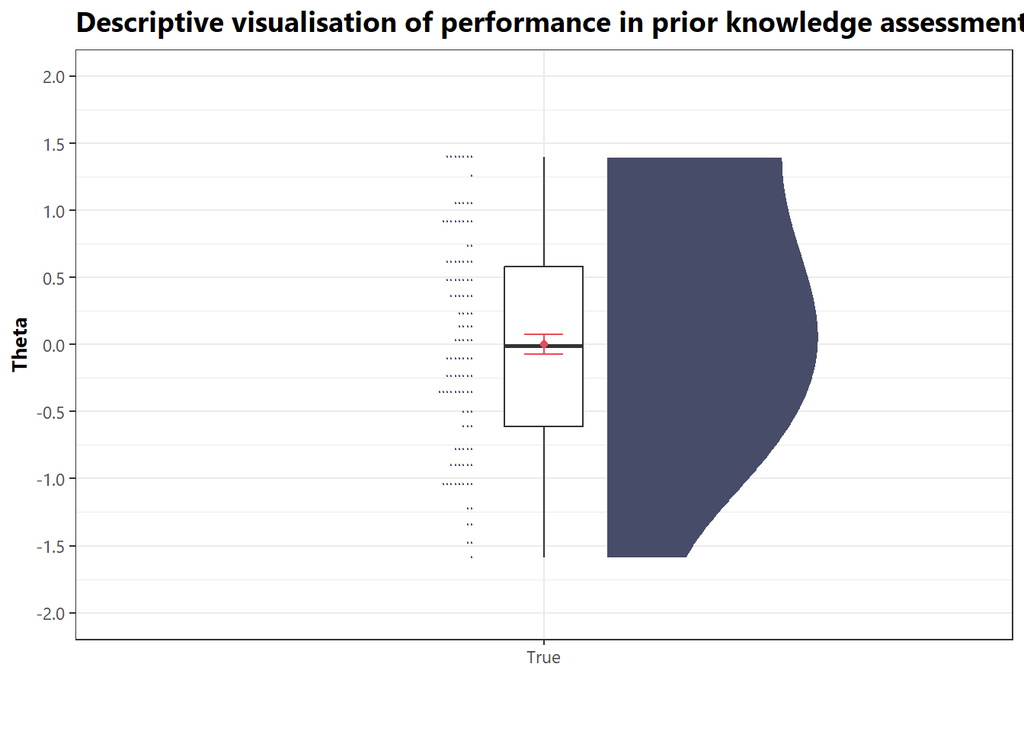

The latent score and sum scores are highly correlated with each other.

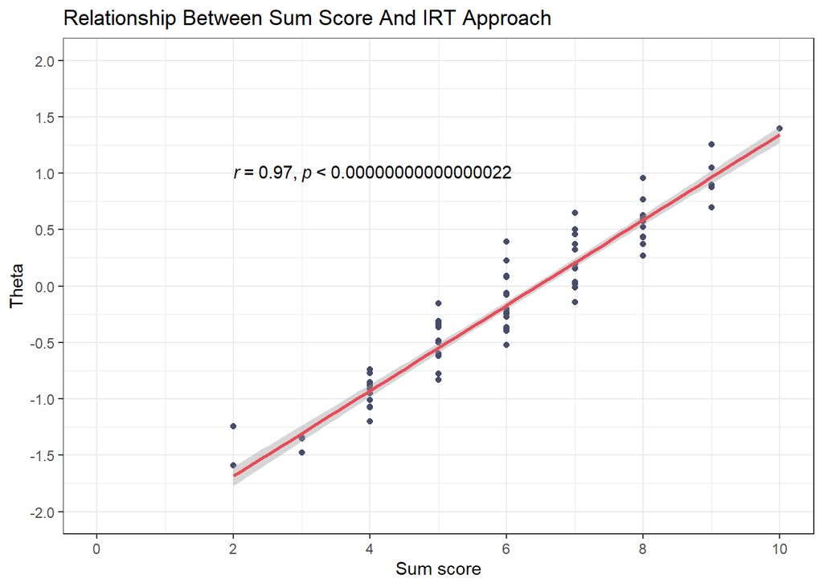